# Logistic Regression with Bayesian Inference

Evan Carey, created for BH Analytics

# The General Linear Model

- We can generalize the ordinary linear model to a more flexible framework
- In regular regression the predictor variables are on the same scale as the outcome
- We assume a normal distribution
  $$E(X) = B_{0} + B_{1}*X_{1} + B_{2}*X_{2} + ... + B_{k}*X_{k} + e$$
- A more general framework would be to allow some function to link the predictors to the outcome
- This is called the link function and in normal regression it is identity
- We can also consider different distributional families for the outcome
- The combination of the link function and the distributional family is the general linear model

# Logistic Regression

$$ln(\frac{P}{1-P}) = B_{0} + B_{1}*X_{1} + B_{2}*X_{2} + ... + B_{k}*X_{k}$$

- In logistic regression we are modeling a binary process, so the outcome takes on 1 of 2 possible values
- The distributional family we use is the binomial distribution, so we assume the outcome follows a binomial distribution
- The main parameter of interest is $p$, the probability of the outcome occurrence
- We use a function called the logit function to link the additive predictor variables to the parameter $p$
- Thus our predictor variables are on the logit scale, not on the outcome ($p$) scale!
- Logistic regression results are often reported as odds ratios, although we do not have to do that

# Logistic Regression

$$ln(\frac{P}{1-P}) = B_{0} + B_{1}*X_{1} + B_{2}*X_{2} + ... + B_{k}*X_{k}$$

- What is our target of inference in this model?
- Where is the error term?

# Visualizing the distribution

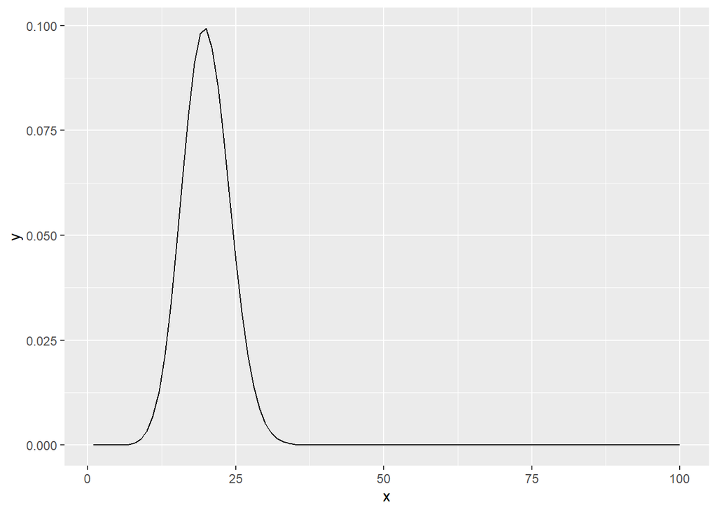

```r
x=1:100
y=dbinom(x,size = 100,prob=0.2)
library(ggplot2)
qplot(x,y,geom = 'line')
```

> Question: Rewrite the above code to explore how this graph changes for different values of p.

# Answer:

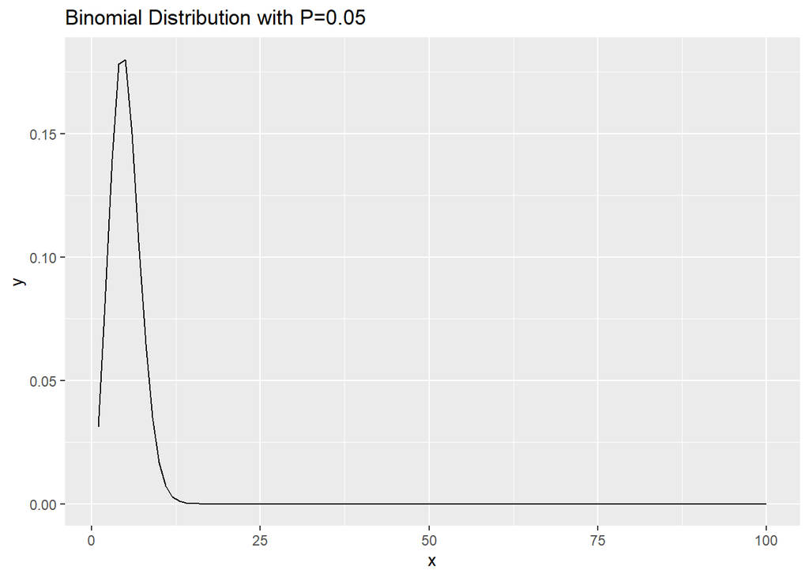

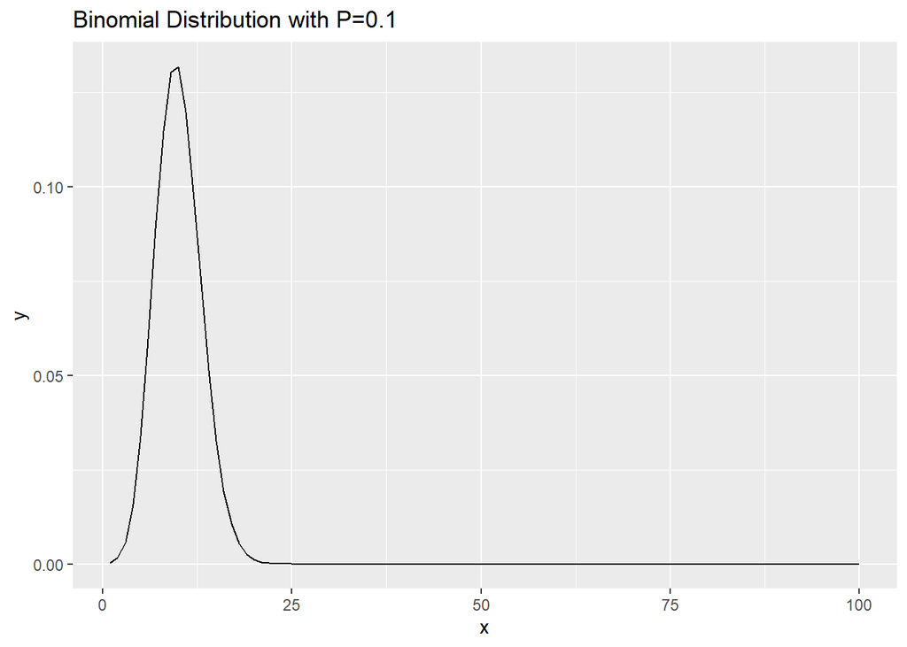

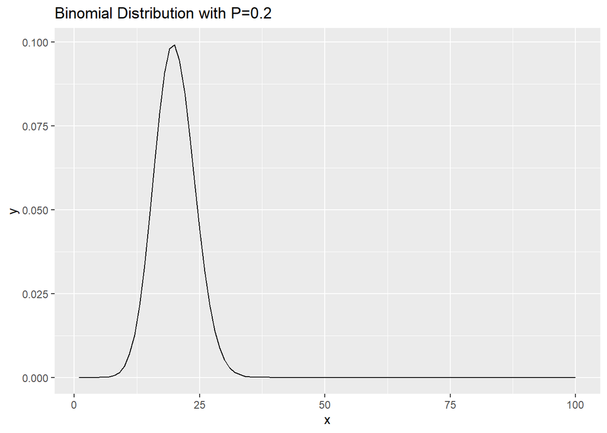

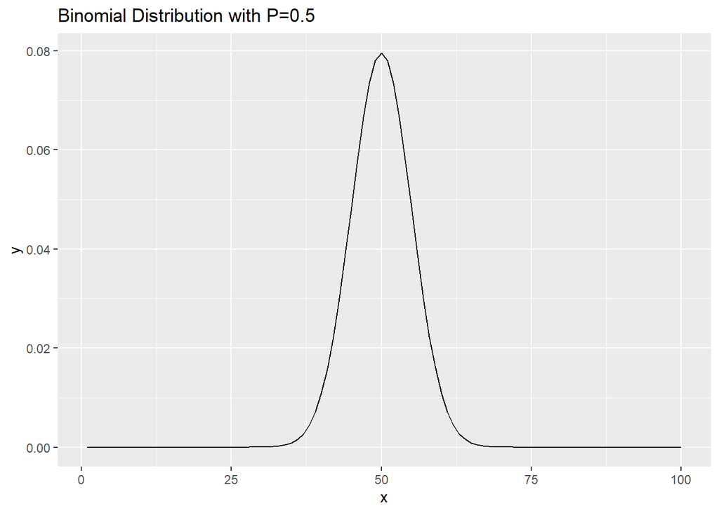

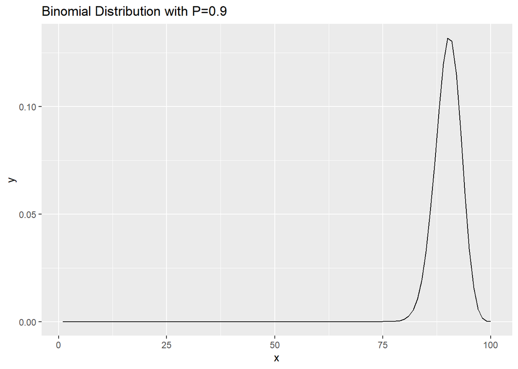

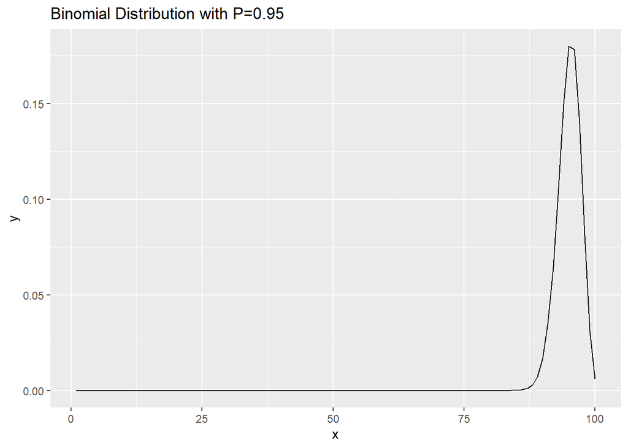

```r
x=1:100
for (i in c(0.05,0.1,0.2,0.5,0.9, 0.95)){
  y=dbinom(x,size = 100,prob=i)
  print(qplot(x,y,geom = 'line',
              main=paste0('Binomial Distribution with P=',i)))
  }
```

# The logit function

- In normal regression, the x and y variables are on the same scale

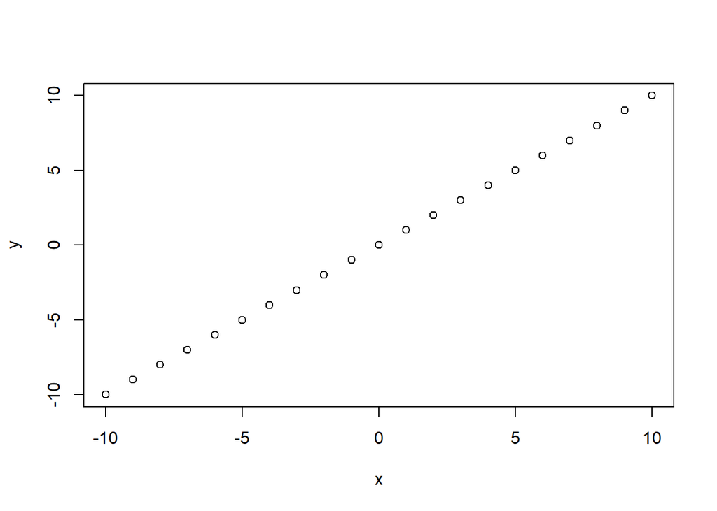

```r
## normal scale
x = -10:10
y = x
plot(x,y)
```

# The logit function

- In logistic regression the x and y variables are related by the logit function

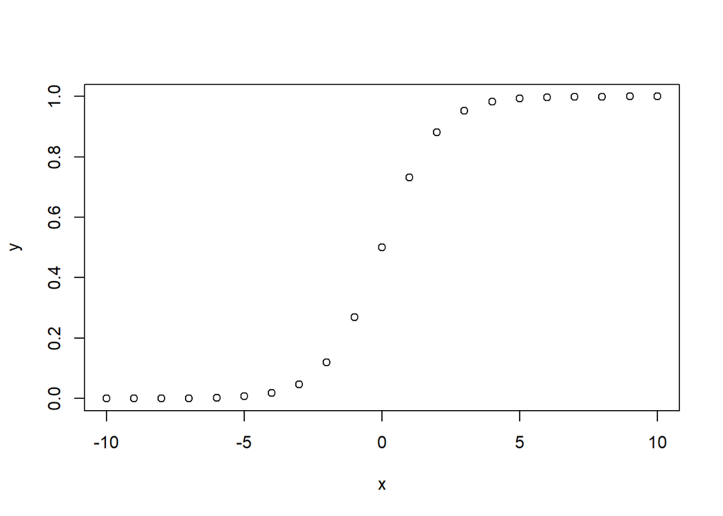

```r
## normal scale
## logit scale
y=plogis(x)
plot(x,y)
```

# The logit function

- Note we can use the `plogis` and `qlogis` functions to go from the predictors to the outcome or vice-versa

```r
## Outcome p = 0.2 to the betas
qlogis(.2)
```

```
## [1] -1.386294
```

```r
## Predictors (Beta) to the probability
plogis(1)
```

```
## [1] 0.7310586
```

# The glm function

- We use the `stan_glm` function for general linear models
- We must specify the link function and the distribution
- A variety of models can be fit in this family
- Normal: link=“identity”, family=“Gaussian”
- Logistic: link=“logit”, family=“binomial”
- Poisson: link=“log”, family=“poisson”
- Gamma: link=“log”, family=“Gamma”
- check the help for “family” and “glm” for more details

```r
## sample logistic regression code
## don't run this code
# stan_glm(cancer ~ gender + smoking, data=mydata,
#     family = binomial(link="logit"))
```

# Birthweight Data

- Lets use the birthweight data set from the MASS package to explore logistic regression
- load this data and examine it

```r
library(MASS)
library(Hmisc)

## load data
data("birthwt")

## Examine Data
str(birthwt)
```

```
## 'data.frame':    189 obs. of  10 variables:
##  $ low  : int  0 0 0 0 0 0 0 0 0 0 ...
##  $ age  : int  19 33 20 21 18 21 22 17 29 26 ...
##  $ lwt  : int  182 155 105 108 107 124 118 103 123 113 ...
##  $ race : int  2 3 1 1 1 3 1 3 1 1 ...
##  $ smoke: int  0 0 1 1 1 0 0 0 1 1 ...
##  $ ptl  : int  0 0 0 0 0 0 0 0 0 0 ...
##  $ ht   : int  0 0 0 0 0 0 0 0 0 0 ...
##  $ ui   : int  1 0 0 1 1 0 0 0 0 0 ...
##  $ ftv  : int  0 3 1 2 0 0 1 1 1 0 ...
##  $ bwt  : int  2523 2551 2557 2594 2600 2622 2637 2637 2663 2665 ...
```

```r
summary(birthwt)
```

```
##       low              age             lwt             race           smoke             ptl               ht                ui
##  Min.   :0.0000   Min.   :14.00   Min.   : 80.0   Min.   :1.000   Min.   :0.0000   Min.   :0.0000   Min.   :0.00000   Min.   :0.0000
##  1st Qu.:0.0000   1st Qu.:19.00   1st Qu.:110.0   1st Qu.:1.000   1st Qu.:0.0000   1st Qu.:0.0000   1st Qu.:0.00000   1st Qu.:0.0000
##  Median :0.0000   Median :23.00   Median :121.0   Median :1.000   Median :0.0000   Median :0.0000   Median :0.00000   Median :0.0000
##  Mean   :0.3122   Mean   :23.24   Mean   :129.8   Mean   :1.847   Mean   :0.3915   Mean   :0.1958   Mean   :0.06349   Mean   :0.1481
##  3rd Qu.:1.0000   3rd Qu.:26.00   3rd Qu.:140.0   3rd Qu.:3.000   3rd Qu.:1.0000   3rd Qu.:0.0000   3rd Qu.:0.00000   3rd Qu.:0.0000
##  Max.   :1.0000   Max.   :45.00   Max.   :250.0   Max.   :3.000   Max.   :1.0000   Max.   :3.0000   Max.   :1.00000   Max.   :1.0000
##       ftv              bwt
##  Min.   :0.0000   Min.   : 709
##  1st Qu.:0.0000   1st Qu.:2414
##  Median :0.0000   Median :2977
##  Mean   :0.7937   Mean   :2945
##  3rd Qu.:1.0000   3rd Qu.:3487
##  Max.   :6.0000   Max.   :4990
```

```r
describe(birthwt)
```

```
## birthwt
##
##  10  Variables      189  Observations
## -----------------------------------------------------------------------------------------------------------------------------------------------------
## low
##        n  missing distinct     Info      Sum     Mean      Gmd
##      189        0        2    0.644       59   0.3122   0.4317
##
## -----------------------------------------------------------------------------------------------------------------------------------------------------
## age
##        n  missing distinct     Info     Mean      Gmd      .05      .10      .25      .50      .75      .90      .95
##      189        0       24    0.996    23.24    5.919       16       17       19       23       26       31       32
##
## lowest : 14 15 16 17 18, highest: 33 34 35 36 45
## -----------------------------------------------------------------------------------------------------------------------------------------------------
## lwt
##        n  missing distinct     Info     Mean      Gmd      .05      .10      .25      .50      .75      .90      .95
##      189        0       75    0.999    129.8    32.12     94.4     99.6    110.0    121.0    140.0    170.0    188.2
##
## lowest :  80  85  89  90  91, highest: 215 229 235 241 250
## -----------------------------------------------------------------------------------------------------------------------------------------------------
## race
##        n  missing distinct     Info     Mean      Gmd
##      189        0        3    0.822    1.847   0.9626
##
## Value          1     2     3
## Frequency     96    26    67
## Proportion 0.508 0.138 0.354
## -----------------------------------------------------------------------------------------------------------------------------------------------------
## smoke
##        n  missing distinct     Info      Sum     Mean      Gmd
##      189        0        2    0.715       74   0.3915    0.479
##
## -----------------------------------------------------------------------------------------------------------------------------------------------------
## ptl
##        n  missing distinct     Info     Mean      Gmd
##      189        0        4    0.403   0.1958   0.3409
##
## Value          0     1     2     3
## Frequency    159    24     5     1
```

[output cut: 13 more lines]

```
##        n  missing distinct     Info     Mean      Gmd
##      189        0        6    0.832   0.7937    1.041
##
## lowest : 0 1 2 3 4, highest: 1 2 3 4 6
##
## Value          0     1     2     3     4     6
## Frequency    100    47    30     7     4     1
## Proportion 0.529 0.249 0.159 0.037 0.021 0.005
## -----------------------------------------------------------------------------------------------------------------------------------------------------
## bwt
##        n  missing distinct     Info     Mean      Gmd      .05      .10      .25      .50      .75      .90      .95
##      189        0      131        1     2945    827.3     1801     2038     2414     2977     3487     3865     3997
##
## lowest :  709 1021 1135 1330 1474, highest: 4167 4174 4238 4593 4990
## -----------------------------------------------------------------------------------------------------------------------------------------------------
```

# Birthwt Data

- We will focus on age, race, lwt (low birth weight), and smoke

```r
## We need to change some of these to factors
## change variables to factor
birthwt$low <- factor(birthwt$low,levels = c(0,1),
                      labels=c("no","yes"))
birthwt$smoke <- factor(birthwt$smoke,levels = c(0,1),
                        labels=c("no","yes"))
birthwt$race <- factor(birthwt$race,levels = c(1,2,3),
                       labels=c("white","black","other"))

## Focus on race, age, lwt, and smoke
```

# Check for Sparse Data

- Sparse data cells can cause issues with logistic regression so let’s create some tables across categorical data elements to check for sparsity.

```r
## Check tables for sparse categorical relationships
xtabs(~low + race + smoke, data=birthwt)
```

```
## , , smoke = no
##
##      race
## low   white black other
##   no     40    11    35
##   yes     4     5    20
##
## , , smoke = yes
##
##      race
## low   white black other
##   no     33     4     7
##   yes    19     6     5
```

# Fit GLM Null Model

```r
library(rstanarm)
library(bayesplot)
CHAINS = 4
SEED = 42

## Run Initial Null Model
mod0 <- stan_glm(low ~ 1,
                 data=birthwt,
                 family = binomial(link = "logit"),
                 chains=CHAINS,
                 seed=SEED)
# Check priors
prior_summary(mod0)
```

```
## Priors for model 'mod0'
## ------
## Intercept (after predictors centered)
##  ~ normal(location = 0, scale = 2.5)
## ------
## See help('prior_summary.stanreg') for more details
```

```r
# This will give an error! Not sure why.
# posterior_vs_prior(mod0)

# Examine model results
summary(mod0,digits=5)
```

```
##
## Model Info:
##  function:     stan_glm
##  family:       binomial [logit]
##  formula:      low ~ 1
##  algorithm:    sampling
##  sample:       4000 (posterior sample size)
##  priors:       see help('prior_summary')
##  observations: 189
##  predictors:   1
##
## Estimates:
##               mean     sd       10%      50%      90%
## (Intercept) -0.79362  0.15236 -0.99027 -0.79317 -0.60102
##
## Fit Diagnostics:
##            mean    sd      10%     50%     90%
## mean_PPD 0.31238 0.04604 0.25397 0.31217 0.37037
##
## The mean_ppd is the sample average posterior predictive distribution of the outcome variable (for details see help('summary.stanreg')).
##
## MCMC diagnostics
##               mcse    Rhat    n_eff
## (Intercept)   0.00398 1.00092 1466
## mean_PPD      0.00104 0.99995 1968
## log-posterior 0.02004 1.00155 1054
##
## For each parameter, mcse is Monte Carlo standard error, n_eff is a crude measure of effective sample size, and Rhat is the potential scale reduction factor on split chains (at convergence Rhat=1).
```

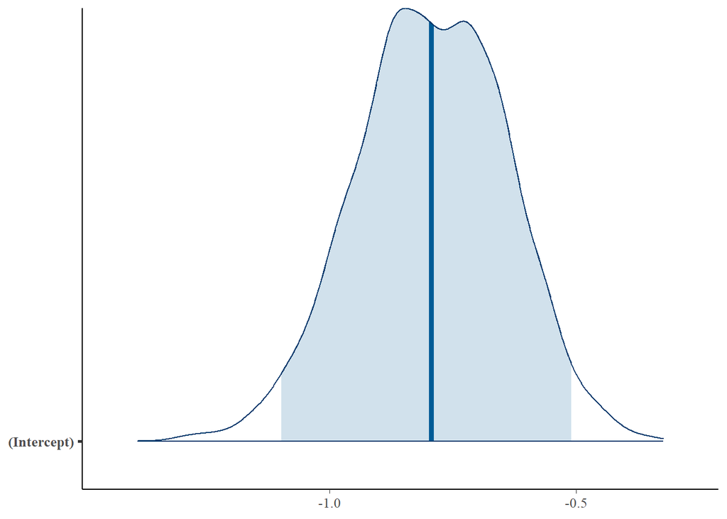

```r
# visualize results
plot(mod0,"areas", prob = 0.95, prob_outer = 1)
```

> The intercept is -0.8. What does that correspond to, why is that?

```r
# Calculate the distribution of low
prop.table(table(birthwt$low))
```

```
##
##        no       yes
## 0.6878307 0.3121693
```

```r
# Model result
coef(mod0)
```

```
## (Intercept)
##   -0.793171
```

```r
plogis(coef(mod0))
```

```
## (Intercept)
##   0.3114882
```

```r
# translate to probability
```

# GLM and the posterior predictions

- A quick commentary about the posterior in a logistic regression (and other GLMs). We now have to differentiate between some things when we say ‘make prediction on the posterior’. If we make predictions for the posterior, there are a few things we could do:
  - **Make predictions of the actual outcome.** In this case, the outcome is a zero or a one (binary outcome!). If we want that, we call the `posterior_predict()` function.
  - **Make predictions about the conditional expectation of the outcome.** In this case, we are making a prediction of the expected value of the outcome. In the case of the logistic regression, this corresponds to the prob of success. We can express this as p (a number between 0 and 1), or we can express this as the linear predictor (sum of the betas). This is exactly what we discussed at the start of the lecture. If we want p, we use `posterior_epred()`. If we want the sum of the betas, we use `posterior_linpred()`.

```r
# examine the posterior (for each parameter, estimated value)
head(as.data.frame(mod0))
```

```
##   (Intercept)
## 1  -0.7931594
## 2  -0.8117102
## 3  -0.8778923
## 4  -0.8635234
## 5  -0.7266023
## 6  -0.9335216
```

```r
# posterior predictions of expected value on outcome scale (prob)
post1 <-
  posterior_epred(mod0)
# posterior predictions of expected value on beta scale scale
post2 <-
  posterior_linpred(mod0)
# posterior predictions on outcome scale (this is zeros and ones)
post3 <-
  posterior_predict(mod0)
```

- Notice the differences in how we might summarize them:

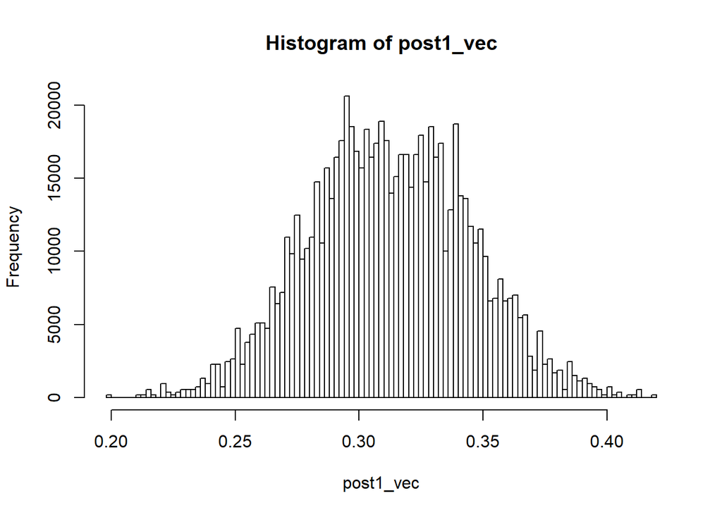

```r
### summarize expected probs
# collapse to vector first - currently there are
# 189 columns and 4000 rows. One column for each observation
# and one row for each posterior sample
# since it is an intercept only model, each column is the same
# in terms of the expectation - so we can collapse to a single vector.
post1_vec <- as.vector(post1)
# graph the posterior probs
hist(post1_vec,breaks = 100)
```

```r
# median
median(post1_vec)
```

```
## [1] 0.3114882
```

```r
# 90% interval
quantile(post1_vec,probs = c(0.05,0.95))
```

```
##        5%       95%
## 0.2597658 0.3652211
```

- We estimate the median predicted probability to be 0.31, with a 90 percent uncertainty interval of (0.26,0.36).

```r
### Summarize the outcome predictions (0/1)
# overall mean
mean(post3)
```

```
## [1] 0.3121124
```

```r
# variability in the mean?
# Summarize each row (each row is one sample)
# the sample mean is the mean of each row, and we have 4000 samples.
row_means <-
  apply(post3,MARGIN = 1,mean)
# now may comments about this distribution of means!
# 90% interval and median
quantile(row_means,probs = c(0.05,0.5,0.95))
```

```
##        5%       50%       95%
## 0.2380952 0.3121693 0.3915344
```

- Notice we have a bit wider confidence interval here. Which one corresponds to the uncertainty interval around the estimated intercept?

```r
# get posterior estimates for intercept, transform to p
quantile(plogis(as.data.frame(mod0)$`(Intercept)`),
         probs= c(0.05,0.5,0.95))
```

```
##        5%       50%       95%
## 0.2597658 0.3114882 0.3652211
```

- The first approach seems correct (assuming we want confidence intervals around the estimated sample mean)!
- My interpretation of it is this:
  - If we want to understand uncertainty in the estimate of the intercept, we use the conditional expectation function `posterior_epred()` or `posterior_linpred()`. This answers the question - what is our estimate of p (the probability of a the outcome), and what is the uncertainty around that estimate? This will correspond to odds ratio when we add in other predictors.
  - If we want to understand uncertainty in an observed sample mean with sample size n=189, given the estimated model parameters, the second approach using `posterior_predict()` is correct.

# Add additional predictors into the model

- There are other variables in the model that may be predictive of the outcome of low birthweight. We add them into the model using the standard R formula like below.

```r
## Model with only age
mod1 <- stan_glm(low ~ age, data = birthwt,
                 family = binomial(link = "logit"),
                 prior = normal(0,2.5),
                 prior_intercept = normal(0,10))
## examine results
summary(mod1)
```

```
##
## Model Info:
##  function:     stan_glm
##  family:       binomial [logit]
##  formula:      low ~ age
##  algorithm:    sampling
##  sample:       4000 (posterior sample size)
##  priors:       see help('prior_summary')
##  observations: 189
##  predictors:   2
##
## Estimates:
##               mean   sd   10%   50%   90%
## (Intercept)  0.4    0.8 -0.5   0.4   1.4
## age         -0.1    0.0 -0.1  -0.1   0.0
##
## Fit Diagnostics:
##            mean   sd   10%   50%   90%
## mean_PPD 0.3    0.0  0.3   0.3   0.4
##
## The mean_ppd is the sample average posterior predictive distribution of the outcome variable (for details see help('summary.stanreg')).
##
## MCMC diagnostics
##               mcse Rhat n_eff
## (Intercept)   0.0  1.0  2358
## age           0.0  1.0  2290
## mean_PPD      0.0  1.0  2949
## log-posterior 0.0  1.0  1505
##
## For each parameter, mcse is Monte Carlo standard error, n_eff is a crude measure of effective sample size, and Rhat is the potential scale reduction factor on split chains (at convergence Rhat=1).
```

# Making predictions from the model

- We can make predictions from the model using either `posterior_linpred()`, which will make predictions of the mean on the either the scale of the betas or the outcome (p in this case).

```r
summary(birthwt$age)
```

```
##    Min. 1st Qu.  Median    Mean 3rd Qu.    Max.
##   14.00   19.00   23.00   23.24   26.00   45.00
```

```r
df1 <- data.frame(age=14:45)
# Generate estimates on the beta scale
pred1_beta <-
  posterior_epred(mod1,
                  newdata = df1)
# Generate estimates transformed to the outcome scale (p)
pred1_p <-
  posterior_epred(mod1,
                  newdata = df1)
# Check dimensionality
dim(pred1_p)
```

```
## [1] 4000   32
```

> Question: Can you figure out how to make a plot summarizing the variation in the estimated relationship between age and birthwt from this posterior distribution?

# Answer to the plotting question

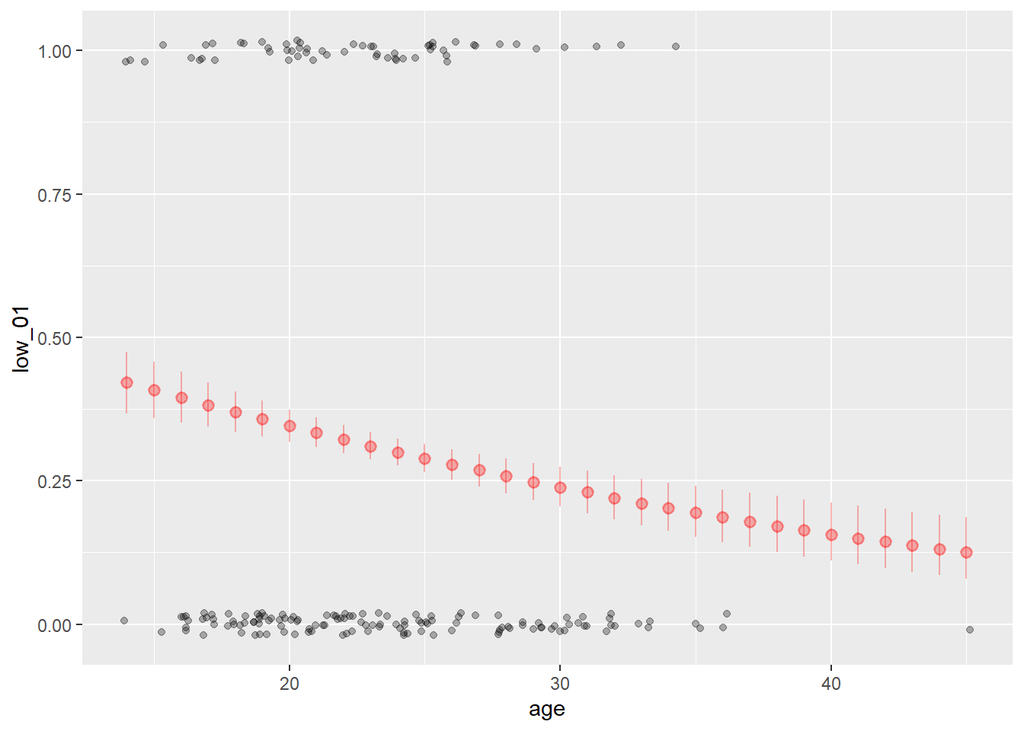

```r
# Create graphical summary of results
df1$pred_50 <- apply(pred1_p,2,median)
df1$pred_25 <- apply(pred1_p,2,quantile,probs=0.25)
df1$pred_75 <- apply(pred1_p,2,quantile,probs=0.75)
birthwt$low_01 <- ifelse(birthwt$low == 'yes', 1, 0)
# Create a plot of the center and 75% density interval
ggplot(data=birthwt,aes(y=low_01,x=age)) +
  geom_jitter(alpha=0.3,height=0.02) +
  geom_pointrange(color='red', alpha=0.3, data=df1,
                  aes(y=pred_50,ymin=pred_25,ymax=pred_75,x=age))
```

# Polynomial Fits in a Logistic Regression

> It looks like the ‘straight line’ fit for age may not be appropriate here. Can you think of a better possible fit, perhaps using a polynomial? Implement this in your code, and visualize the result as we did above.

# Polynomial Fits in a Logistic Regression

> It looks like the ‘straight line’ fit for age may not be appropriate here. Can you think of a better possible fit, perhaps using a polynomial? Implement this in your code, and visualize the result as we did above.

```r
## Model with only age
mod2 <- stan_glm(low ~ age + I(age**2), data = birthwt,
                 family = binomial(link = "logit"),
                 prior = normal(0,2.5),
                 prior_intercept = normal(0,10))
## examine results
summary(mod2)
```

```
##
## Model Info:
##  function:     stan_glm
##  family:       binomial [logit]
##  formula:      low ~ age + I(age^2)
##  algorithm:    sampling
##  sample:       4000 (posterior sample size)
##  priors:       see help('prior_summary')
##  observations: 189
##  predictors:   3
##
## Estimates:
##               mean   sd   10%   50%   90%
## (Intercept) -3.9    3.3 -8.2  -3.8   0.2
## age          0.3    0.3  0.0   0.3   0.7
## I(age^2)     0.0    0.0  0.0   0.0   0.0
##
## Fit Diagnostics:
##            mean   sd   10%   50%   90%
## mean_PPD 0.3    0.0  0.3   0.3   0.4
##
## The mean_ppd is the sample average posterior predictive distribution of the outcome variable (for details see help('summary.stanreg')).
##
## MCMC diagnostics
##               mcse Rhat n_eff
## (Intercept)   0.1  1.0  1053
## age           0.0  1.0  1064
## I(age^2)      0.0  1.0  1073
## mean_PPD      0.0  1.0  1911
## log-posterior 0.0  1.0   944
##
## For each parameter, mcse is Monte Carlo standard error, n_eff is a crude measure of effective sample size, and Rhat is the potential scale reduction factor on split chains (at convergence Rhat=1).
```

```r
# Save df results
summary(birthwt$age)
```

```
##    Min. 1st Qu.  Median    Mean 3rd Qu.    Max.
##   14.00   19.00   23.00   23.24   26.00   45.00
```

```r
df2 <- data.frame(age=14:45)
# Generate estimates transformed to the outcome scale (p)
pred2_p <- posterior_epred(mod2,
                           newdata = df2)
# Check dimensionality
dim(pred2_p)
```

```
## [1] 4000   32
```

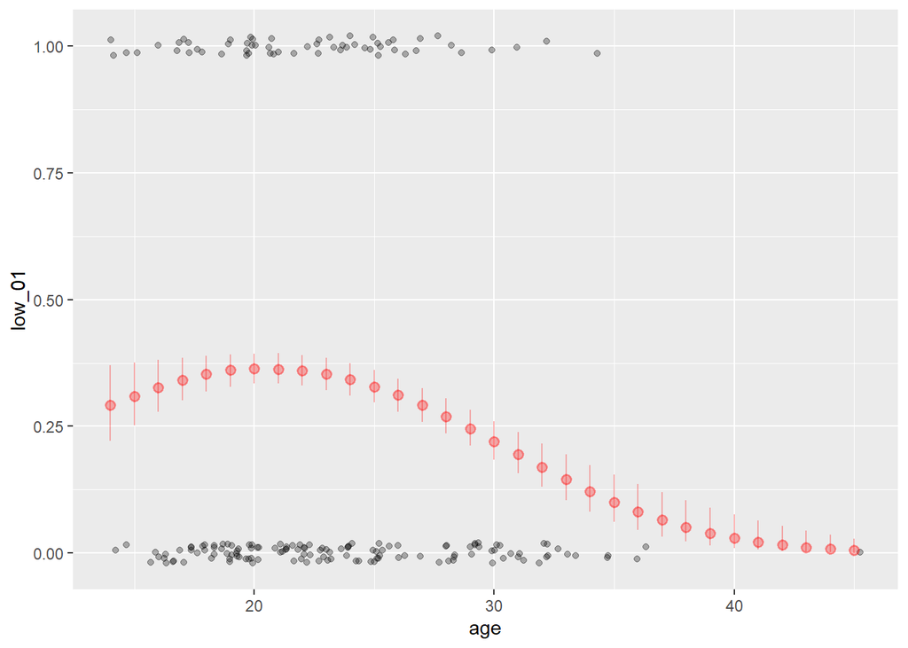

```r
# Create graphical summary of results
df2$pred_50 <- apply(pred2_p,2,median)
df2$pred_25 <- apply(pred2_p,2,quantile,probs=0.25)
df2$pred_75 <- apply(pred2_p,2,quantile,probs=0.75)
# Create a plot of the center and 75% density interval
ggplot(data=birthwt,aes(y=low_01,x=age)) +
  geom_jitter(alpha=0.3,height=0.02) +
  geom_pointrange(color='red', alpha=0.3, data=df2,
                  aes(y=pred_50,ymin=pred_25,ymax=pred_75,x=age))
```

# Add in more predictors

- We can also add in smoking status like so:

```r
## Model with age and smoking status
mod3 <- stan_glm(low ~ age + I(age**2) + smoke, data = birthwt,
                 family = binomial(link = "logit"),
                 prior = normal(0,2.5),
                 prior_intercept = normal(0,10))
## examine results
summary(mod3)
```

```
##
## Model Info:
##  function:     stan_glm
##  family:       binomial [logit]
##  formula:      low ~ age + I(age^2) + smoke
##  algorithm:    sampling
##  sample:       4000 (posterior sample size)
##  priors:       see help('prior_summary')
##  observations: 189
##  predictors:   4
##
## Estimates:
##               mean   sd   10%   50%   90%
## (Intercept) -4.3    3.3 -8.6  -4.1  -0.2
## age          0.3    0.3  0.0   0.3   0.7
## I(age^2)     0.0    0.0  0.0   0.0   0.0
## smokeyes     0.7    0.3  0.3   0.7   1.1
##
## Fit Diagnostics:
##            mean   sd   10%   50%   90%
## mean_PPD 0.3    0.0  0.3   0.3   0.4
##
## The mean_ppd is the sample average posterior predictive distribution of the outcome variable (for details see help('summary.stanreg')).
##
## MCMC diagnostics
##               mcse Rhat n_eff
## (Intercept)   0.1  1.0  1637
## age           0.0  1.0  1631
## I(age^2)      0.0  1.0  1622
## smokeyes      0.0  1.0  2102
## mean_PPD      0.0  1.0  2681
## log-posterior 0.0  1.0  1335
##
## For each parameter, mcse is Monte Carlo standard error, n_eff is a crude measure of effective sample size, and Rhat is the potential scale reduction factor on split chains (at convergence Rhat=1).
```

# Model Comparisons

You can use the same leave-one-out cross-validation method here to compare the model fits using the loo package and function.

```r
loo1 <- loo(mod1)
loo2 <- loo(mod2)
loo3 <- loo(mod3)
loo_compare(loo1,loo2,loo3)
```

```
##      elpd_diff se_diff
## mod3  0.0       0.0
## mod1 -1.1       2.5
## mod2 -1.5       2.2
```

# Summarizing Uncertainty in Functions of Parameters

> Question: How would you create a table of odds ratios and the associated confidence intervals for the smoke parameter? Hint: We generate OR’s by exponentiating the beta Hint: Use the as.data.frame() function on the model fit to extract the posterior draws for each parameter

# Summarizing Uncertainty in Functions of Parameters

> Question: How would you create a table of odds ratios and the associated confidence intervals for the smoke parameter?  
> Hint: We generate OR’s by exponentiating the beta
- Answer

```r
## get posterior draws
mod3_posterior <- as.data.frame(mod3)
mod3_posterior$smoke_OR <- exp(mod3_posterior$smokeyes)
quantile(mod3_posterior$smoke_OR,
         probs=c(0.1, 0.5, 0.9))
```

```
##      10%      50%      90%
## 1.345609 1.993970 3.024511
```

# Exercise

- Check the other variables in the dataset, specifically ht (history of hypertension) and ui (presence of uterine irritability)
- Investigate if these variables are related to the outcome using the same sort of modeling approach we have just done. Start by modeling them as the only predictor, then add them into the full model with smoke and age. Create a table of Odds Ratio’s for the adjusted and unadjusted results and summarize them.